# Predict Corrrect Weight Lifting Exercise Using Accelerometers Data

Roberto Arce

March 22, 2016

# Summary

This report use the data from accelerometers to predict the correct realization of Weight Lifting Exercise, we use Random Forest getting a great cross validation accuracy on the training set. We predict the outcome for 20 data point of the test set.

# Introduction

Using devices such as Jawbone Up, Nike FuelBand, and Fitbit it is now possible to collect a large amount of data about personal activity relatively inexpensively. These type of devices are part of the quantified self movement – a group of enthusiasts who take measurements about themselves regularly to improve their health, to find patterns in their behavior, or because they are tech geeks. One thing that people regularly do is quantify how much of a particular activity they do, but they rarely quantify how well they do it.

In this project, we use data from accelerometers on the belt, forearm, arm, and dumbell of 6 participants, asked to perform barbell lifts correctly and incorrectly in 5 different ways. **Our goal is to predict the manner in which they did the exercise.**

# Exploratory Data Analysis and Preprocessing

The data for this project come from the [Weight Lifting Exercise Dataset](http://groupware.les.inf.puc-rio.br/har). The Dataset contains the accelerometers data from six participants performing one set of 10 repetitions of the Unilateral Dumbbell Biceps Curl in five different fashions: exactly according to the specification (Class A), throwing the elbows to the front (Class B), lifting the dumbbell only halfway (Class C), lowering the dumbbell only halfway (Class D) and throwing the hips to the front (Class E). Class A corresponds to the specified execution of the exercise, while the other 4 classes correspond to common mistakes.

The dataset for this project was prevously splited in training and test set. The trainning set is composed of 19622 observations and the test of 20 observations.

```r
raw_train = read.csv("data/pml-training.csv",na.strings=c("NA",""))
raw_test = read.csv("data/pml-testing.csv",na.strings=c("NA",""))
```

The data is composed by 160 variables including `classe`, the outcome variable. We remove the some variable, the row number, timestamp, the subject name and exercise window vars, who don’t measure the exersice execution.

```r
keep_cols = !(colnames(raw_train) %in% c("X","raw_timestamp_part_1","raw_timestamp_part_2","cvtd_timestamp","new_window","num_window","user_name"))
train = raw_train[,keep_cols]
test = raw_test[,keep_cols]
```

There are few examples with all variables set, only 406 examples in the training dataset.

```r
sum(complete.cases(train))
```

```
## [1] 406
```

```r
mostly_data<-apply(!is.na(train),2,sum)>19621
train<-train[,mostly_data]
test<-test[,mostly_data]
dim(train)
```

```
## [1] 19622    53
```

# Model

We use random forest models to predict, the random forest model have many features, for example work with NA data, realize feature selection and get state of the art performance in mostly of the machine learning problems. First at all we load `caret` and setup ´doMC´ to fit the models using parallel processing.

```r
suppressMessages(suppressWarnings(library(caret)))
suppressMessages(suppressWarnings(library(doMC)))
control <- trainControl(method="cv", 10)
registerDoMC(8) # use 8 core, change if is diferent
```

We fit a **Random Forest** model, using **10-fold** cross-validation.

```r
suppressMessages(suppressWarnings(library(randomForest)))
set.seed(1)
model_rf <- train(as.factor(classe) ~ ., data=train, method="rf", trControl=control, parallel=TRUE)
```

## Model performance

```r
model_rf
```

```
## Random Forest
##
## 19622 samples
##    52 predictor
##     5 classes: 'A', 'B', 'C', 'D', 'E'
##
## No pre-processing
## Resampling: Cross-Validated (10 fold)
## Summary of sample sizes: 17659, 17660, 17660, 17660, 17659, 17659, ...
## Resampling results across tuning parameters:
##
##   mtry  Accuracy   Kappa      Accuracy SD  Kappa SD
##    2    0.9950564  0.9937466  0.001154253  0.001460141
##   27    0.9949547  0.9936178  0.001235289  0.001562328
##   52    0.9899092  0.9872349  0.001516327  0.001918272
##
## Accuracy was used to select the optimal model using  the largest value.
## The final value used for the model was mtry = 2.
```

In the following we see the confusion matrix of the model, this show us there is no miss-prediction over the training set.

```r
predict_train <- predict(model_rf, train)
confusionMatrix(train$classe, predict_train)$table
```

```
##           Reference
## Prediction    A    B    C    D    E
##          A 5580    0    0    0    0
##          B    0 3797    0    0    0
##          C    0    0 3422    0    0
##          D    0    0    0 3216    0
##          E    0    0    0    0 3607
```

## Most important variables

From the fitted model we can see the most important variables, the following plot show us, `roll_belt` is the most important feature follow by `yaw_belt`.

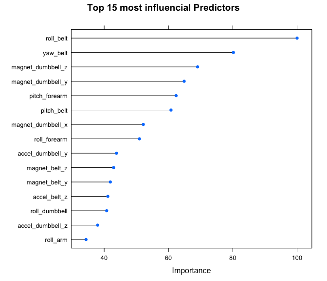

```r
plot(varImp(model_rf), main = "Top 15 most influencial Predictors", top = 15)
```

# Predicting Test Set

Finally the prediction for the test set is the following.

```r
predict_test <- predict(model_rf, test)
predict_test
```

```
##  [1] B A B A A E D B A A B C B A E E A B B B
## Levels: A B C D E
```